# Trade Calculator

## Ziel

Ziel dieses Prozesses soll es sein, einen Trade Calculatot für die RFL zu haben, anhand dessen der Wert für Spieler und Draftpicks abgeschätzt werden kann.

### Spieler Values

Ausgangslage für die Wertbestimmung eines Spielers sind seine durchschnittlichen Fantasy Points per Game (PPG).

In die Berechnung einfließen tuen noch das Alter des Spielers (bzw. die Anzahl der Jahre, in denen er in der NFL spielt), die Anzahl bisher verpasster Spiele und der Positional Value.

### Pick Values

Um den Wert von Draftpicks zu bestimmen wird zum einen geschaut, welche WAR die Spieler erzielten, die mit den gleichen Picks ausgewählt wurden und zum anderen für welche Spieler sie bisher getradet wurden.

**Der Wert von Assets ist immer schwankend und wird sich mit jeder Transaktion ändern.**

## WAR

Um den Wert von Spielern nicht nur anhand seiner aktuellen Perfromance zu bewerten, werden auch vergangene WAR mit eingerechnet. Aber wie predictive sind WAR überhaupt? Dazu schauen wir mal, in wie weit sich die aktuellen WAR mit denen der Vergangenheit erklären lassen. Auf der y-Achse haben wir immer die WAR der Saison, die wir betrachten und auf der x-Achse die WAR der Saison - n. n ist dabei immer ein Zeitraum von einem Jahr zurück. Im ersten Plot schauen wir also auf die WAR der aktuellen und der letzten Saison, im letzten Plot auf die aktuelle und die Saison vor 5 Jahren.

[figure not shown]

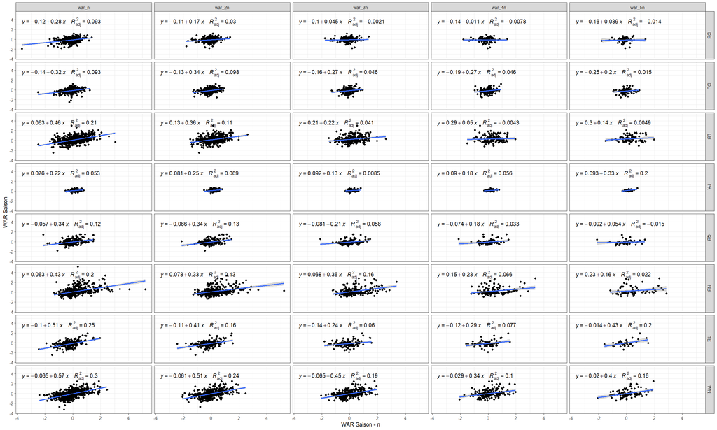

Die Formeln, um den Wert der Spieler zu bestimmen, lauten also:

| Pos | n | Formel |
| --- | --- | --- |
| QB | 2 | WAR + (-0.0572045609072629 + 0.335805189854136 * WAR n-1) + (-0.0656352626313826 + 0.340018928615608 * WAR n-2) |
| RB | 1 | WAR + (0.0632856170854548 + 0.427800971341318 * WAR n-1) |
| WR | 2 | WAR + (-0.0652000581945214 + 0.56611412469965 * WAR n-1) + (-0.0606074704348276 + 0.509887090841478 * WAR n-2) |
| TE | 2 | WAR + (-0.10185570549546 + 0.510696456478246 * WAR n-1) + (-0.11197695453321 + 0.41227635843769 * WAR n-2) |
| PK | 2 | WAR + (0.0761457565624674 + 0.220795423946824 * WAR n-1) + (0.0805129058322742 + 0.250410612271745 * WAR n-2) |
| DL | 2 | WAR + (-0.136330981596147 + 0.32218930505515 * WAR n-1) + (-0.128015460184296 + 0.33825013289081 * WAR n-2) |
| LB | 1 | WAR + (0.0633587228377668 + 0.464357584085741 * WAR n-1) |
| DB | 0 | WAR |

Betrachten wir die derzeit wertvollsten Spieler jeder Positionsgruppe nach der WAR Berechnung:

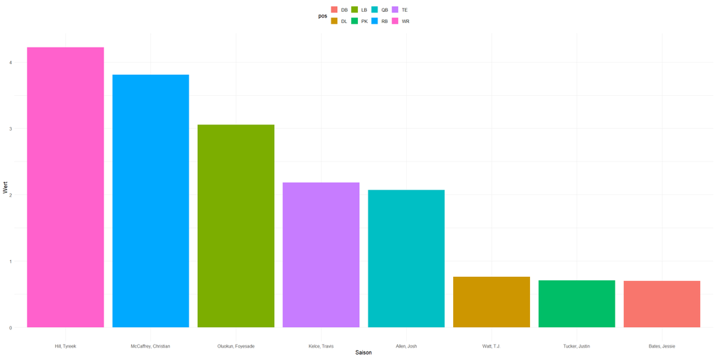

## Aging Curves

Das Alter von Spielern ist in Dynasty Ligen sehr relevant, wenn es um die Einschätzung seines Wertes geht. Aber wie lässt sich das statistisch belegen? Dazu schauen wir uns alle Spieler an, die in den letzten 20 Jahren in die NFL gekommen sind. Wir berechnen anhand der RFL Punkte Regeln ihre PPG und gruppieren diese Werte nach Draft Round.

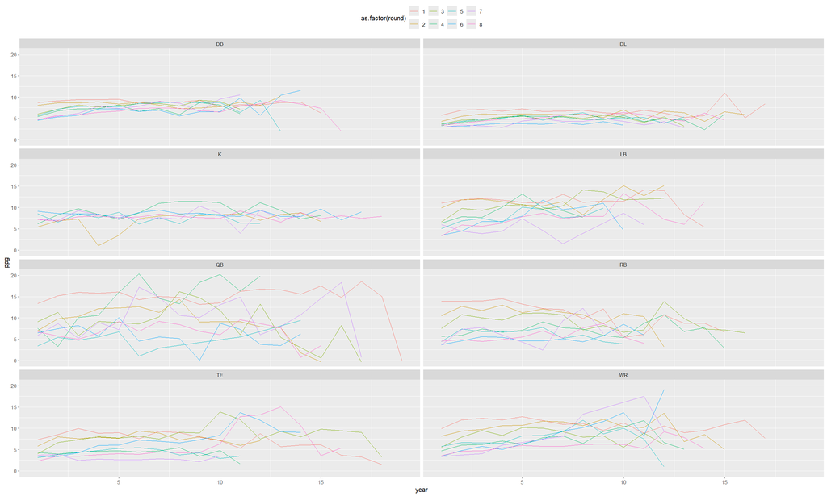

Wenn wir daraus prozentuale Werte berechnen, erhalten wir die folgende Tabelle (Beispiel anhand aller 1st Round Picks):

| year | round | DB | DL | K | LB | QB | RB | TE | WR |
| --- | --- | --- | --- | --- | --- | --- | --- | --- | --- |
| 1 | 1 | 1.01 | 0.84 | NA | 0.98 | 0.91 | 1.29 | 1.06 | 0.93 |
| 2 | 1 | 1.05 | 1.03 | NA | 1.05 | 1.04 | 1.28 | 1.23 | 1.12 |
| 3 | 1 | 1.09 | 1.05 | NA | 1.07 | 1.10 | 1.29 | 1.44 | 1.15 |
| 4 | 1 | 1.09 | 1.00 | NA | 1.04 | 1.08 | 1.34 | 1.27 | 1.12 |
| 5 | 1 | 1.10 | 1.06 | NA | 0.99 | 1.10 | 1.22 | 1.29 | 1.19 |
| 6 | 1 | 0.98 | 0.98 | NA | 0.98 | 0.98 | 1.13 | 1.09 | 1.11 |
| 7 | 1 | 1.04 | 0.99 | NA | 1.16 | 1.02 | 1.11 | 1.34 | 1.02 |
| 8 | 1 | 1.02 | 1.03 | NA | 0.99 | 1.01 | 0.92 | 1.30 | 1.04 |
| 9 | 1 | 1.08 | 0.93 | NA | 1.02 | 0.90 | 1.12 | 1.15 | 0.89 |
| 10 | 1 | 0.90 | 0.90 | NA | 1.01 | 0.92 | 0.51 | 1.03 | 1.05 |
| 11 | 1 | 0.95 | 1.03 | NA | 1.26 | 1.11 | 0.57 | 0.77 | 0.83 |
| 12 | 1 | 0.95 | 0.93 | NA | 1.24 | 1.14 | 0.99 | 1.26 | 0.99 |
| 13 | 1 | 1.02 | 0.77 | NA | 0.74 | 1.13 | 0.81 | 0.82 | 0.84 |
| 14 | 1 | 1.02 | 0.83 | NA | 0.48 | 1.06 | 0.81 | 0.87 | 0.89 |
| 15 | 1 | 0.72 | 1.63 | NA | NA | 1.20 | 0.61 | 0.89 | 1.01 |
| 16 | 1 | NA | 0.76 | NA | NA | 1.01 | NA | 0.53 | 1.11 |
| 17 | 1 | NA | 1.24 | NA | NA | 1.27 | NA | 0.47 | 0.72 |
| 18 | 1 | NA | NA | NA | NA | 1.03 | NA | 0.21 | NA |
| 19 | 1 | NA | NA | NA | NA | 0.00 | NA | NA | NA |

Hier sieht man zB ganz gut, dass 1st Round RBs im Schnitt in den ersten 4 Jahren ihrer Karriere die meisten Punkte machen und dann ein deutlicher Abwärtstrend beginnt.

Da in Dynastyligen in mittelfristigen Zeiträumen gedacht wird, werden wir für die Berechnung immer die nächsten 5 Jahre einbeziehen.

Das ist der Multiplikator, mit dem der WAR Wert des Spielers verrechnet wird.

| year | round | DB | DL | K | LB | QB | RB | TE | WR |
| --- | --- | --- | --- | --- | --- | --- | --- | --- | --- |
| 1 | 1 | 1.0619969 | 1.0228907 | NA | 1.02457188 | 1.0558886 | 1.2547846 | 1.26454970 | 1.1370393 |
| 2 | 1 | 1.0594860 | 1.0156399 | NA | 1.04725707 | 1.0532683 | 1.2192330 | 1.28594067 | 1.1172590 |
| 3 | 1 | 1.0458532 | 1.0121928 | NA | 1.03217825 | 1.0362918 | 1.1439611 | 1.25796669 | 1.0948032 |
| 4 | 1 | 1.0433811 | 0.9996771 | NA | 1.02909552 | 1.0009895 | 1.0994729 | 1.23315904 | 1.0481475 |
| 5 | 1 | 1.0035313 | 0.9659926 | NA | 1.03266830 | 0.9667602 | 0.9556607 | 1.17925370 | 1.0217142 |
| 6 | 1 | 0.9961358 | 0.9761679 | NA | 1.08834426 | 0.9929625 | 0.8428006 | 1.11508785 | 0.9657495 |
| 7 | 1 | 0.9769853 | 0.9627863 | NA | 1.10461551 | 1.0168732 | 0.8198220 | 1.09960090 | 0.9590392 |
| 8 | 1 | 0.9762851 | 0.9112787 | NA | 1.05329527 | 1.0415192 | 0.7981703 | 1.00371430 | 0.9188106 |
| 9 | 1 | 0.9643530 | 0.8909965 | NA | 0.94467713 | 1.0741834 | 0.7354161 | 0.94830411 | 0.9191369 |
| 10 | 1 | 0.9295074 | 1.0372148 | NA | 0.74239397 | 1.1286577 | 0.7574056 | 0.92081843 | 0.9104955 |
| 11 | 1 | 0.7401970 | 0.9841296 | NA | 0.49138567 | 1.1097015 | 0.6443250 | 0.87328245 | 0.9678738 |
| 12 | 1 | 0.5510709 | 1.0472559 | NA | 0.24333040 | 1.1347658 | 0.4461007 | 0.71491327 | 0.9135854 |
| 13 | 1 | 0.3480306 | 0.8929102 | NA | 0.09567846 | 1.1132739 | 0.2846822 | 0.59333693 | 0.7457156 |
| 14 | 1 | 0.1448317 | 0.7264227 | NA | 0.09567846 | 0.9006541 | 0.1229975 | 0.41951519 | 0.5676231 |
| 15 | 1 | 0.1448317 | 0.4011588 | NA | NA | 0.6612903 | 0.1229975 | 0.24190788 | 0.3655566 |
| 16 | 1 | NA | 0.2483833 | NA | NA | 0.4589532 | NA | 0.13596808 | 0.1430967 |
| 17 | 1 | NA | 0.2483833 | NA | NA | 0.2051792 | NA | 0.04227983 | 0.1430967 |
| 18 | 1 | NA | NA | NA | NA | 0.2051792 | NA | 0.04227983 | NA |
| 19 | 1 | NA | NA | NA | NA | 0.0000000 | NA | NA | NA |

```r
player_values <- player_war_values %>%
  dplyr::select(season, player_id, player_name, pos, player_war_value) %>%
  dplyr::mutate(player_id = as.character(player_id)) %>%
  dplyr::left_join(
    nflreadr::load_ff_playerids() %>%
      dplyr::select(mfl_id, gsis_id),
    by = c("player_id" = "mfl_id")
  ) %>%
  dplyr::left_join(
    nflreadr::load_players() %>%
      dplyr::select(gsis_id, entry_year),
    by = "gsis_id"
  ) %>%
  dplyr::left_join(
    ppg_value %>%
      dplyr::group_by(player_id) %>%
      dplyr::summarise(
        multi_games = mean(multi_games, na.rm = TRUE),
        career_ppg = mean(ppg, na.rm = TRUE),
        ppg_over_replacement = mean(ppg_over_replacement, na.rm = TRUE)
      ),
    by = c("gsis_id" = "player_id")
  ) %>%
  dplyr::filter(!is.na(gsis_id)) %>%
  dplyr::left_join(
    nflreadr::load_draft_picks() %>%
      dplyr::select(gsis_id, round),
    by = "gsis_id"
  ) %>%
  dplyr::mutate(
    round = ifelse(is.na(round), 8, round),
    year = season - entry_year + 1
  ) %>%
  dplyr::select(-season, -entry_year, -gsis_id) %>%
  dplyr::left_join(
    aging_curves_multi %>%
      dplyr::select(position, year, round, multi_n5),
    by = c("pos" = "position", "year", "round")
  ) %>%
  dplyr::group_by(pos) %>%
  dplyr::arrange(dplyr::desc(ppg_value)) %>%
  dplyr::mutate(
    #proj_ppg = ppg_value * multi_n5,
    #proj_fpts = proj_ppg * 13 * 15 * 0.75,
    #ppg_value = ifelse(is.na(ppg_value), 0, ppg_value),
    #ppg_value = ppg_value + (min(ppg_value) * -1), # normalize auf 0
    #ppg_value_pct = ppg_value / max(ppg_value)
  )
```

[output not shown]

## Positional Value

### Anteil an den Lineup Punkten

Für den Positional Value schauen wir auf die Starter aller Fantasy Matchups der letzten zwei Jahre. Wir beschränken und auf diesen Zeitraum um mögliche Trends genauer abbilden zu können. Wir schauen wie groß der Einfluss der einzelnen Positionsgruppe an den Gesamtpunkten des Teams war.

### Positionsdichte

Als zweiten Faktor für den Positional Value untersuchen wir die Dichte der Positionsgruppe. Dazu ranken wir die Positionsgruppe absteigend nach ihrem bereits berechneten WAR Value und filtern den letzten Starter heraus. Diesen bekommen wir durch die Anzahl der im Schnitt gestarteten Spieler pro Positionsgruppe.

```r
position_depth <- player_war_values %>%
  dplyr::group_by(pos) %>%
  dplyr::arrange(dplyr::desc(player_war_value)) %>%
  dplyr::mutate(pos_rank = dplyr::row_number()) %>%
  dplyr::left_join(
    positional_value %>%
      dplyr::select(pos, position_count),
    by = "pos",
    multiple = "all"
  ) %>%
  dplyr::filter(pos_rank <= ceiling(position_count * 12)) %>%
  dplyr::filter(pos_rank == max(pos_rank)) %>%
  dplyr::rename(last_starter_war_value = player_war_value) %>%
  dplyr::select(pos, last_starter_war_value) %>%
  dplyr::ungroup()

position_depth %>%
  dplyr::arrange(dplyr::desc(last_starter_war_value)) %>%
  gt::gt()
```

[output not shown]

## Player Value

Führen wir die Daten zusammen:

1. Wir haben den Wert des Spielers an sich (*player_war_value*), gemessen in WAR unter Berücksichtigung der letzten Jahre (siehe oben)
2. Wir haben den Wert der Positionsgruppe (*position_value*), gemessen in einem Prozentualem Anteil am Ergebnis des Teams
3. Wir haben den Wert der Positionsgruppe, gemessen in WAR des letzten Starters (*last_starter_war_value*)

Keinen Einfluss haben (derzeit): - Alter des Spielers (aging curve einberechnen) - Umstände (zB Depth Chart Position, Spieler anderer Units, Coaching etc.) - Vertrag des Spielers

Aus allem ergibt sich die Formel:

**player_value = (player_war_value + positional_war_value) * player_war_value_pct**

## Picks

Der Wert von Draftpicks wird anhand der WAR der Spieler berechnet, die in vorherigen Drafts gepickt wurden. Dazu ermitteln wir von jedem Draftpick die durchschnittlichen WAR der ersten 3 Jahre nach dem Draft. Dann sortieren wir die Picks absteigend nach den durchschnittlichen WAR und erhalten eine Reihenfolge, in der die Spieler optimalerweise hätten gepickt werden sollen und damit auch den Wert der Picks. Dann ermitteln wir den durschnitt aus allen Drafts, die bereits mindestens eine Saisons zurückliegen.

```r
pick_values <- league_drafts_raw %>%
  dplyr::filter(is_rookie == 1) %>%
  dplyr::left_join(
    player_war_raw %>%
      dplyr::filter(season >= 2017) %>%
      dplyr::group_by(player_id) %>%
      dplyr::arrange(season) %>%
      dplyr::mutate(years_in_league = dplyr::row_number()) %>%
      dplyr::filter(years_in_league <= 3) %>%
      dplyr::group_by(player_id) %>%
      dplyr::summarise(war_3y_avg = mean(war, na.rm = TRUE)) %>%
      dplyr::select(player_id, war_3y_avg),
    by = c("mfl_id" = "player_id")
  ) %>%
  dplyr::filter(!is.na(war_3y_avg)) %>%
  dplyr::select(-overall:-franchise) %>%
  dplyr::distinct() %>%
  dplyr::group_by(season) %>%
  dplyr::arrange(dplyr::desc(war_3y_avg)) %>%
  dplyr::mutate(overall_war = dplyr::row_number()) %>%
  dplyr::group_by(overall_war) %>%
  dplyr::summarise(pick_value = mean(war_3y_avg)) %>%
  dplyr::filter(!is.na(pick_value)) %>%
  dplyr::arrange(dplyr::desc(pick_value)) %>% # dadurch, dass in manchen drafts nicht alle picks gemacht wurden, kommt es hier zu fehlern. deshalb wird neu sortiert
  dplyr::mutate(overall_war = dplyr::row_number()) %>%
  dplyr::mutate(
    pick_value_norm = round((-1 * min(pick_value)) + pick_value, 2),
    pick_value_pct = pick_value / max(pick_value)
  )

ggplot2::ggplot(pick_values, ggplot2::aes(x = overall_war, y = pick_value)) +
  geom_line() +
  labs(
    x = "Overall Clean",
    y = "Avg. WAR der ersten 3 Jahre seit 2017"
  )
```

[output not shown]

Da es 3 Kopien pro Spieler gibt, erstellen wir noch eine Matrix für alle Picks.

```r
pick_values_overall <- tibble(
  overall = 1:252,
  overall_clean = ceiling(overall / 3)
) %>%
  dplyr::left_join(
    pick_values,
    by = c("overall_clean" = "overall_war")
  ) %>%
  dplyr::mutate(
    round = ceiling(overall / 36),
  ) %>%
  dplyr::group_by(round) %>%
  dplyr::mutate(
    round_avg = round(mean(pick_value), 2),
    pick = dplyr::row_number(),
    pick_readable = paste0("Pick ", round, ".", pick),
    round = dplyr::case_when(
      round == 1 ~ "1st",
      round == 2 ~ "2nd",
      round == 3 ~ "3rd",
      TRUE ~ paste0(round, "th")
    ),
    time = dplyr::case_when(
      pick <= 12 ~ paste("Early", round),
      pick <= 24 ~ paste("Mid", round),
      pick <= 36 ~ paste("Late", round)
    )
  ) %>%
  dplyr::ungroup()

ggplot2::ggplot(pick_values_overall, ggplot2::aes(x = overall, y = pick_value)) +
  geom_line() +
  labs(
    x = "Overall Pick",
    y = "Avg. WAR der ersten 3 Jahre seit 2017"
  )
```

[output not shown]

In dem Prozess gehen wir davon aus, dass die Spieler mit den selben WAR immer 3 mal hintereinander gedraftet werden. Das bedeutet, dass eine Pick-Gruppe von 3 aufeinander folgenden Picks den selben Value hat.

```r
trade_values <- player_values %>%
  dplyr::mutate(
    asset = paste0(player_name, " (", pos, ")")
  ) %>%
  dplyr::rename(value = player_value) %>%
  dplyr::select(asset, value) %>%
  dplyr::bind_rows(
    pick_values_overall %>%
      dplyr::select(pick_readable, pick_value) %>%
      dplyr::rename(asset = pick_readable, value = pick_value)
  ) %>%
  dplyr::bind_rows(
    pick_values_overall %>%
      dplyr::select(time, pick_value) %>%
      dplyr::group_by(time) %>%
      dplyr::summarise(value = mean(pick_value), .groups = "drop") %>%
      dplyr::rename(asset = time)
  ) %>%
  dplyr::mutate(
    value = round(value, 2)
  )

readr::write_csv(trade_values, "../data/trade-calculator/trade-values.csv")
```

### Future Picks

- Alle Jahre haben gleiche Wertigkeit
- Nicht definierte Runden Picks (zB next Years 1st) erhalten einen gemittelten Wert der gesamten Runde.

## Trades

Nur Spieler mit mind. 20% der Total Points von max Pts der Positionsgruppe

# Positional Value

## Tiers

### Was sind Tiers?

Die Gliederung von Spielern in Tiers beschreibt das Zusammenfassen einer beliebigen Anzahl von Spielern der gleichen Positionsgruppe in eine Gruppe (Tier). Ein Tier soll alle darin enthaltenen Spieler möglichst genau in ihrer Fantasy Production beschreiben. Das 1. Tier beinhaltet immer die wertvollsten Spieler einer Positionsgruppe.

### Wie werden Tiers definiert?

Es gibt keinen Konsens wie Tiers eingeteilt werden. Da wir den generellen Wert einer Positionsgruppe ermitteln wollen, wird mit den Daten aus den letzten drei Jahren gearbeitet.

Wir werden die Points per Game (PPG) und die Varianz der PPG nutzen. Varianz beschreibt dabei die Beständigkeit, in der ein Spieler seine PPG erzielt hat. Hohe Varianz bedeutet, dass der Spieler oft sehr weit über oder unter seinem Durchschnitt perormt hat (unbeständig). Eine niedrige Varianz bedeutet im Umkehrschluss, der Spieler hat konstant seinen Durchschnitt an Fantasy Punkten erzielt (beständig).

#### Cluster

# https://rpubs.com/scunden/positional-value

# https://statsandr.com/blog/clustering-analysis-k-means-and-hierarchical-clustering-by-hand-and-in-r/#consensus-based-algorithm